# Activation of Color in First and Second Language Vocabulary Processing

Published: 2024-6-13; Last Update (JST) 2024-07-11 19:25:04.217236

## Introduction

[interactive chart not shown]

## Embodied cognition framework

- Humans not only understand the lexical meaning of a word but also evoke their accumulated experiences (e.g., seeing, touching, and eating the objects) associated with the word (e.g., **Barsalou, et al., 2008**).

[interactive chart not shown]

## Connell and Lynott (2009)

- Activation of Objects’ color
- Semantic Stroop task
  1. Read a sentence (e.g., *Joe was excited to see a bear in the woods.*)
  2. The keyword is presented in color ( **bear** )
  3. Answer the color of the font
- [Demo video](https://youtu.be/WFRbEMdWlXY)

## Connell and Lynott (2009)

### What they found

- When the indicated color and the font color matched, the reaction times were faster than mismatched.
- Sentence (*Joe was excited to see a bear in the woods*): 🐻
- Matched: word ( **bear** ): **Faster**
- Mismatched: word ( **bear** ): **Slower**

## Processing in Second Language

### Difference between learning and acquisition

- Context of English Learning in Japan
  - **English:** primarily learned in classrooms as a foreign language.
  - **Japanese:** naturally acquired

[interactive chart not shown]

## Processing in Second Language

[interactive chart not shown]

- *Note*. The Figure from Norman and Peleg (2022, p 412)

## Terai (2023)

- Replicated Connell and Lynott (2009) in both first and second language
- Interaction of second language proficiency and typicality (Second language)

  Second language proficiency was operationalized using the vocabulary size scores.

[interactive chart not shown]

## Limitations

### It still remains unclear whether:

- Second Language vocabulary size matters
  - **Possibility:** Faster recognition speed leads to a stronger Stroop effect?
- The magnitude of the Stroop effect is greater in the first language compared to the second language
  - **Recommendation:** Use Language as a within-subject design

## The Study

## Research Hypotheses

1 The reaction times (RTs) for typical color words are fastest, while those for unrelated and atypical words are slower (Stroop effects)

- Readers activate object’s color in both first and second languages (e.g., Terai, 2023)

2 As RTs in lexical decision tasks (LDT) become faster, the Stroop effect becomes more pronounced.

- Strongly embodied words are processed faster.

3 The Stroop effect is bigger in Japanese tasks compared to English tasks.

- First language knowledge is more embodied than second language knowledge

## Participants

- Native Japanese speakers (*N* = 38)
  - University or junior college students in Japan
  - Two participants had study abroad experience, with a maximum duration of one month.

## Experimental Materials

### Stroop Task

- 15 nouns from Terai (2023)
  - apple, ball, bear, cake, chameleon, cloud, horse, kiwi, leaf, onion, plum, popcorn, steak, strawberry, and tomato
- Color-Typicality Combinations
  - e.g.

| Words | Typical Color | Atypical Color | Unrelated Color |
| --- | --- | --- | --- |
| tomato | RED | GREEN | WHITE |
| bear | BROWN | WHITE | GREEN |
| onion | BROWN | WHITE | RED |

## Experiments

### on-site

1 Participants completed both the Stroop and LDT tasks in both English and Japanese.

- ([**Stroop Task**](https://youtu.be/Oy42jekWjzI))
- ([**LDT**](https://youtu.be/pHg8mFHS05s))

2 Word-Typicality Rating Task

[interactive chart not shown]

- 1: never comes to mind
- 6: comes to mind first

## Analysis

## Coding

### Typicality Check

- In cases of disagreements, the typicality-color combinations were adjusted based on the participants’ responses.
- e.g.
  - Researcher
    - red tomato: typical
    - green tomato: atypical
  - a participant
    - red tomato: atypical
    - green tomato: typical
- Adjusted Coding
  - red tomato: typical **atypical**
  - green tomato: atypical **typical**

Adjustments were made at the level of each individual word.

## Descriptive Statistics

## English

| Typicality | Mean (Mu & Tau) | Mu | Sigma | Tau | Rhat |
| --- | --- | --- | --- | --- | --- |
| typical | 963.33 | 686.41 | 61.41 | 276.93 | 1 |
| unrelated | 1025.60 | 734.56 | 88.49 | 291.04 | 1 |
| atypical | 1058.48 | 743.51 | 73.87 | 314.98 | 1 |

<sup>a</sup> Reaction times in milliseconds.  
<sup>b</sup> The descriptive statistics were calculated by fitting an ex-Gaussian distribution to the data.

## Japanese

| Typicality | Mean (Mu & Tau) | Mu | Sigma | Tau | Rhat |
| --- | --- | --- | --- | --- | --- |
| typical | 1003.40 | 707.93 | 59.62 | 295.47 | 1 |
| unrelated | 1010.75 | 725.17 | 77.89 | 285.58 | 1 |
| atypical | 1016.53 | 737.16 | 84.62 | 279.37 | 1 |

<sup>a</sup> Reaction times in milliseconds.  
<sup>b</sup> The descriptive statistics were calculated by fitting an ex-Gaussian distribution to the data.

## Bayesian GLMM

## Model Formula

```r
# brm function of brms package
brm(

  # Dependent variable
  formula = RT.Stroop ~ ## Reaction times of the Stroop task

  # Independent variables
  z.RT.LDT *     ## Reaction times of the LDT
  typicality_new *  ## Color typicality
  Lang +  ## Language of the task (English, Japanese)

  # Random Effects
  (1 + z.RT.LDT * typicality_new * Lang|PiD) + ## Participants
  (1 + z.RT.LDT * typicality_new * Lang|Word), ## Words

  # Probablistic distribution
  family = exgaussian(link = "identity",
                        link_sigma = "log",
                        link_beta = "log"),

  # Prior distribution
  prior = c(
            prior(cauchy(0, 2), class = Intercept),
            prior(cauchy(0, 2), class = b),
            prior(cauchy(0, 2), class = sd)
            ),

  # Other settings
  chains = 4, # nb of chains
  iter = 10000, # nb of iterations, including burnin
  warmup = 5000, # burnin
  thin = 2,    # thinning
  seed = 123  # random seed

  )
```

## Modeling Results

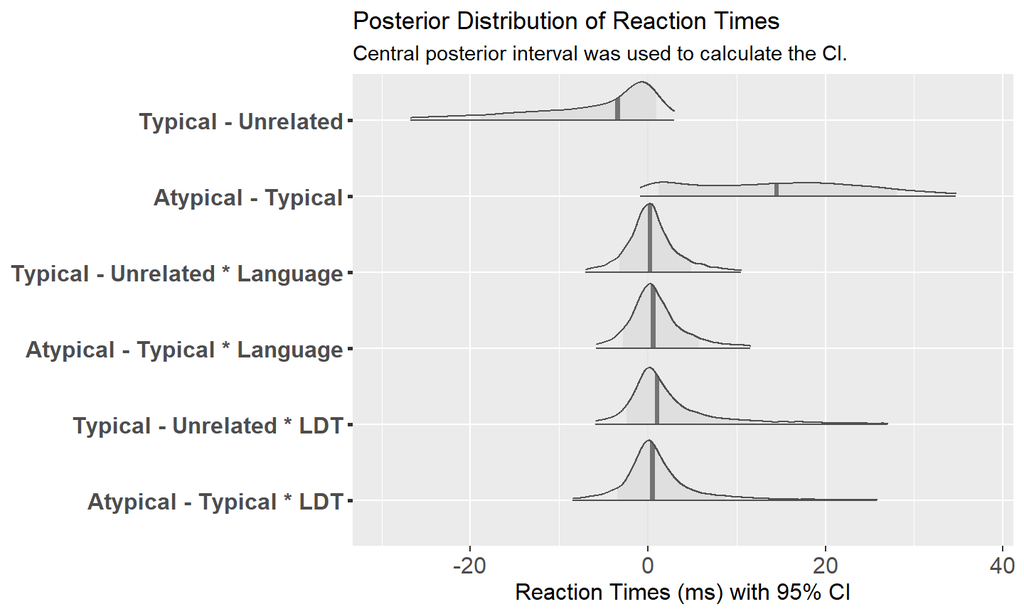

## Modeling Results

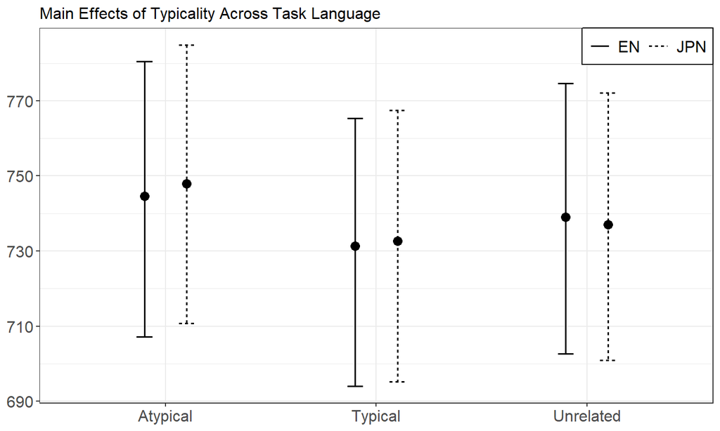

## Discussion

## Research Hypothesis 1

RT of the Stroop task for typical color words are fastest, while those for unrelated and atypical words are slower.

### Weakly Supported

- Typical colors elicited faster reaction times than atypical or unrelated colors.
  - Readers activate object’s color
- **However, the intervals included 0 or the opposite values.**
  - The current study: Words
  - Previous studies: Sentence → words (e.g., Connell & Lynott, 2009; Terai, 2023)

## Research Hypothesis 2

As RTs in LDT faster, the Stroop effect becomes more pronounced.

### Not Supported

- The data distribution has its peaks near 0.
  - There is a weaker relationship between the recognition speed and the magnitude of the Stroop effect.
- The degree of color activation may not be related to the speeding up of word recognition.
  - The participants might focus mainly on letters (superficial process) in LDT task.

## Research Hypothesis 3

The Stroop effect is bigger in Japanese tasks compared to English tasks.

### Not Supported

- The data distribution shows peaks near 0.
  - Most words are represented similarly in Japanese **katakana**.

    | English | Katakana |
    | --- | --- |
    | apple | アップル |
    | ball | ボール |
    | bear | ベア― |
    | cake | ケーキ |
    | chameleon | カメレオン |
    | cloud | クラウド |
    | horse | ホース |
    | kiwi | キウイ |
    | leaf | リーフ |
    | onion | オニオン |
    | plum | プラム |
    | popcorn | ポップコーン |
    | steak | ステーキ |
    | strawberry | ストロベリー |
    | tomato | トマト |

- The referred objects represent the same colors.
- Culturally different items might be more interesting
  - sun
    - red (Japan)
    - yellow (America)

## Conclusion

### Readers appeared to demonstrate color activation when presented with words in both their first and second languages.

- However, the evidence is weak

### Recognition speed of each word might not be an useful measure to examine the degree of the embodiment of the word.

## References

- [Barsalou, L. W. (2008). Grounded cognition. *Annual Review of Psychology, 59*, 617–645.](https://doi.org/10.1146/annurev.psych.59.103006.093639)
- [Chen, D., Wang, R., Zhang, J., & Liu, C. (2020). Perceptual representations in L1, L2 and L3 comprehension: Delayed sentence–picture verification. *Journal of Psycholinguistic Research, 49*(1), 41–57.](https://doi.org/10.1007/s10936-019-09670-x)
- [Connell, L., & Lynott, D. (2009). Is a bear white in the woods? Parallel representation of implied object color during language comprehension. *Psychonomic Bulletin and Review, 16*(3), 573–577.](https://doi.org/10.3758/PBR.16.3.573)
- [Norman, T., & Peleg, O. (2022). The reduced embodiment of a second language. *Bilingualism: Language and Cognition, 25*(3), 406–416.](https://doi.org/10.1017/s1366728921001115)
- [Norman, T., & Peleg, O. (2023). Visual simulations in the two cerebral hemispheres: A bilingual perspective. *Brain and Language, 242*, 105291.](https://doi.org/10.1016/j.bandl.2023.105291)
- [Terai, M. (2023). *Activation of Color Information in Second Language Comprehension*, Doctoral dissertation, Nagoya University.](https://nagoya.repo.nii.ac.jp/records/2005609)

## This is the end of the slide